# Phase 03 — Exploratory Data Analysis

**Project:** Education and Income Inequality — A Cross-Country Panel Analysis **Phase:** 03 — Exploratory Data Analysis **Author:** Kota **Last executed:** auto-stamped at notebook execution time (see footer)

## Abstract

This notebook characterises the analytical panel constructed in Phase 02 (`data/processed/panel.csv`, 7,378 country-year rows × 19 declared variables covering 217 countries from 1990 to 2023) along five axes — distributions, bivariate relationships, multicollinearity, temporal patterns, and geographic patterns. The goal is to surface the structural facts that constrain Phase 05's econometric specifications and motivate the Phase 04 country clustering.

The headline findings preview the synthesis at the foot of this notebook: **mean years of schooling is the strongest single linear predictor of Gini** (r = −0.52, OLS R² = 0.27); **the three secondary-enrolment variables are arithmetically nested** with VIFs in the 9,000–40,000 range and must be deconfounded before modelling; **the secondary-vs-tertiary enrolment story is well captured linearly** but `enrol_primary` and `mean_years_schooling` show meaningful non-linearity (LOWESS Δ R² > 0.10) that a linear baseline will under-fit; **`edu_expenditure_gdp` is the only candidate predictor with a null bivariate signal**, suggesting policy framing should distinguish input intensity from attainment outcomes; and **the income-group view of Gini is consistent with a Kuznets-type inverted-U** in which middle-income countries are most unequal, not the lowest-income ones.

This notebook does *not* make causal claims. EDA describes; Phase 05's panel econometrics estimate associations under stated assumptions; Phase 07 discusses what those associations can and cannot license.

## 1. Framing

Phase 03 sits between data infrastructure (Phases 01–02) and analytical modelling (Phases 05–06). Its output is not a model but a **diagnostic landscape**: per-variable shape, pairwise relationships, joint multicollinearity structure, temporal evolution, and geography. Each of these directly informs at least one downstream design choice.

| Phase 03 finding axis | Phase 04/05/07 design choice it informs |
| --- | --- |
| Univariate distribution (skew, modality) | log-transform decisions; robustness to outliers |
| Bivariate (LOWESS vs linear) | linear baseline vs polynomial; transformation choice |
| Correlation / VIF | variable selection in regression specifications |
| Time-series by region / income | clustering features; convergence narrative |
| Geographic | cross-country heterogeneity claims; missingness narrative |

The interpretation of every figure follows a three-layer structure: **Observation** (what the figure literally shows), **Explanation** (the likely structural cause), **Implication** (what this changes for downstream phases). EDA describes; it does not conclude. Where natural language suggests causation we hedge with "consistent with" or "may indicate".

The seven Phase 03 design decisions logged at the top of Step 01 (`PROJECT_LOG.md`, entry dated 2026-04-30) are taken as given here. In particular: choropleths are rendered with plotly to avoid the geopandas dependency surface; both `region_name` and `income_level_name` carry narrative load (geography vs structure); skewed economic variables are shown raw alongside log; VIF flagging is stratified at thresholds 5 (watch) and 10 (concern); pre-2000 enrolment sparsity is shown not truncated; and unemployment lines start at 1991 (ILO modeled-series start year) with a footnote rather than restricting the entire panel.

## 2. Setup

```python
from pathlib import Path

import numpy as np
import pandas as pd
from IPython.display import Image, IFrame, display, Markdown

import sys
sys.path.insert(0, str(Path.cwd().parent))
from src.paths import find_project_root
from src.manifest import load_manifest, manifest_variable_order

PROJECT_ROOT = find_project_root(Path.cwd())
PANEL_PATH = PROJECT_ROOT / "data" / "processed" / "panel.csv"
MANIFEST_PATH = PROJECT_ROOT / "data" / "raw" / "manifest.yaml"
FIG_DIR = PROJECT_ROOT / "outputs" / "figures"
TBL_DIR = PROJECT_ROOT / "outputs" / "tables"

panel = pd.read_csv(PANEL_PATH)
manifest = load_manifest(MANIFEST_PATH)
var_order = manifest_variable_order(manifest)

print(f"Panel shape: {panel.shape[0]:,} rows x {panel.shape[1]} columns")
print(f"Year range: {panel['year'].min()}-{panel['year'].max()}")
print(f"Countries: {panel['iso3'].nunique()}")
print(f"Declared variables (manifest order): {len(var_order)}")
```

```
Panel shape: 7,378 rows x 24 columns
Year range: 1990-2023
Countries: 217
Declared variables (manifest order): 19
```

## 3. Univariate distributions

The first diagnostic is the per-variable shape: where each of the 19 declared variables sits, how concentrated or dispersed its values are, and whether a transformation is warranted before modelling. The grid below shows histograms for all 19 variables. For three economic variables whose raw distributions are heavily right-skewed (`gdp_per_capita_usd`, `gdp_per_capita_ppp`, `population`), the log- transformed view is shown alongside the raw view. Each subplot annotates its observed N and Fisher–Pearson skewness.

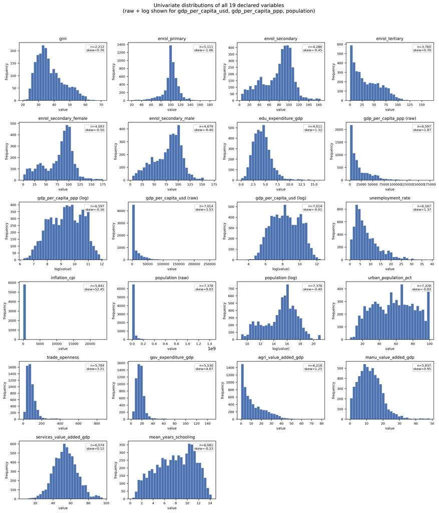

**Skewness reduction under log transform:**

| transform | variable | skew_log | skew_raw |
| --- | --- | --- | --- |
| 0 | gdp_per_capita_ppp | -0.159581 | 1.865719 |
| 1 | gdp_per_capita_usd | -0.006702 | 3.533191 |
| 2 | population | -0.404088 | 9.031769 |

```python
display(Image(filename=str(FIG_DIR / "phase03_s02_univariate_distributions.png")))

skew_df = pd.read_csv(TBL_DIR / "phase03_s02_skewness.csv")

# Pivot to compare raw vs log for the three log-paired variables.
log_pairs = (
    skew_df[skew_df["variable"].isin(["gdp_per_capita_usd",
                                       "gdp_per_capita_ppp",
                                       "population"])]
    .pivot(index="variable", columns="transform", values="skewness")
    .rename(columns={"raw": "skew_raw", "log": "skew_log"})
    .reset_index()
)
display(Markdown("**Skewness reduction under log transform:**"))
display(log_pairs)
```

**Explanation.** Per-capita GDP and population are multiplicative quantities by their nature, so distributions over countries are approximately log-normal — the log transform recovers near-Gaussian shape mechanically rather than as a modelling trick. The inflation distribution is dominated by a handful of hyperinflation country-years (most plausibly Zimbabwe, Venezuela, mid-1990s post-Soviet states); these are real observations, not data errors, but a single-coefficient linear treatment would let them dominate the fit. `enrol_primary` shows a ceiling because gross enrolment ratios above 100% reflect over-age enrolment, not coverage beyond 100%, and many countries have stabilised near or just above this ceiling.

**Implication.** Phase 05 will apply log transformations to `gdp_per_capita_*` and `population` at modelling time (consistent with the Phase 02 schema decision to store raw values). `inflation_cpi` requires either a log transform or winsorisation; the presence of a non-trivial set of country-years with inflation above 1,000% means a naive log can still leave the distribution heavy-tailed and a robust regression diagnostic will be needed in Phase 05. `enrol_primary`'s ceiling means the linear relationship between primary enrolment and Gini is structurally bounded above and is unlikely to be informative at the high end — a finding that recurs in the bivariate analysis below.

## 4. Bivariate analysis: Gini vs candidate predictors

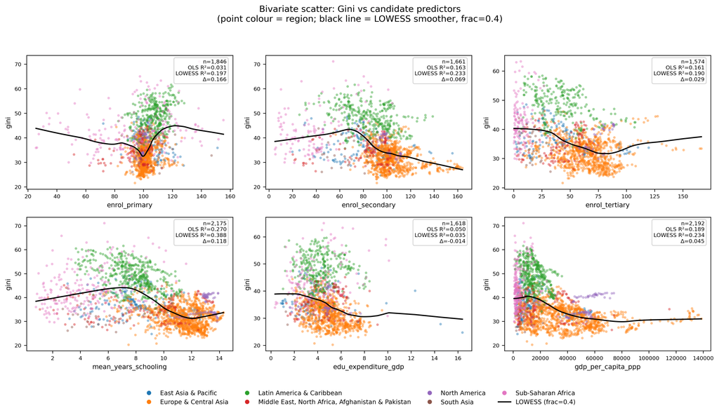

**LOWESS vs OLS linear fit, Gini as response:**

|  | predictor | n | ols_slope | ols_r2 | lowess_r2 | delta_r2 |
| --- | --- | --- | --- | --- | --- | --- |
| 0 | enrol_primary | 1846 | +0.1289 | 0.031 | 0.197 | +0.166 |
| 1 | enrol_secondary | 1661 | -0.1307 | 0.163 | 0.233 | +0.069 |
| 2 | enrol_tertiary | 1574 | -0.1163 | 0.161 | 0.190 | +0.029 |
| 3 | mean_years_schooling | 2175 | -1.4931 | 0.270 | 0.388 | +0.118 |
| 4 | edu_expenditure_gdp | 1618 | -1.1881 | 0.050 | 0.035 | -0.014 |
| 5 | gdp_per_capita_ppp | 2192 | -0.0002 | 0.189 | 0.234 | +0.045 |

```python
display(Image(filename=str(FIG_DIR / "phase03_s03_bivariate_gini.png")))

lowess_df = pd.read_csv(TBL_DIR / "phase03_s03_lowess_vs_linear.csv")
display(Markdown("**LOWESS vs OLS linear fit, Gini as response:**"))
display(lowess_df.style.format({
    "ols_slope": "{:+.4f}",
    "ols_r2": "{:.3f}",
    "lowess_r2": "{:.3f}",
    "delta_r2": "{:+.3f}",
}))
```

**Observation.** `mean_years_schooling` is the strongest single linear predictor (OLS R² = 0.27, slope = −1.49 Gini points per additional year of schooling). `enrol_secondary` and `enrol_tertiary` show clean negative linear relationships (OLS R² ≈ 0.16 each). `gdp_per_capita_ppp` (raw) gives R² = 0.19 with a near-zero linear slope reflecting its scale rather than its effect. `enrol_primary` has the lowest OLS R² (0.03) but the largest LOWESS-vs-linear gap (Δ = 0.166). `edu_expenditure_gdp` is the only predictor where the LOWESS fit is *worse* than linear (Δ = −0.014), i.e. there is essentially no structure for the smoother to capture.

**Explanation.** The rank ordering is consistent with the standard story that *attainment* (years of schooling actually accumulated) carries more information about a country's stratification than any single *flow* indicator (current enrolment) — a stock vs flow distinction. The near-zero slope on `gdp_per_capita_ppp` reflects the units (Gini is in 0–100 percentage-point units, GDP per capita in tens of thousands of dollars), not the lack of association; the R² is the meaningful number. The large LOWESS gap for `enrol_primary` is an artefact: the relationship is non-monotonic because both the lowest-Gini countries (high-income, near universal primary enrolment) and the highest-Gini countries (Latin America, also near universal primary enrolment) cluster around 100% gross enrolment, so a linear fit produces a near-zero coefficient with the "wrong" sign. The null result for `edu_expenditure_gdp` is real — public education expenditure as a share of GDP is not, by itself, predictive of the income distribution.

**Implication.** Phase 05's baseline specification should anchor on `mean_years_schooling` as the primary education variable. `enrol_secondary` and `enrol_tertiary` work well as linear regressors. `enrol_primary` should not enter a linear specification as a single term — its relationship is non-monotonic and a misleading positive coefficient is likely; if retained at all it should be in a polynomial or interaction form. The null on `edu_expenditure_gdp` is itself a Phase 07 narrative: input intensity is not the same as attainment, and the policy implications differ correspondingly.

## 5. Correlation and multicollinearity

Pairwise correlations and Variance Inflation Factors (VIF) measure the joint structure of the predictor set. Pearson correlation is computed pairwise-complete across all 19 declared variables (so each cell uses the maximum N for that pair). VIF is computed on the listwise-complete subset of the 18 right-hand-side variables (gini excluded, as it is the target), and is stratified at two thresholds per Phase 03 design Decision 4: VIF above 5 is "watch", above 10 is "concern".

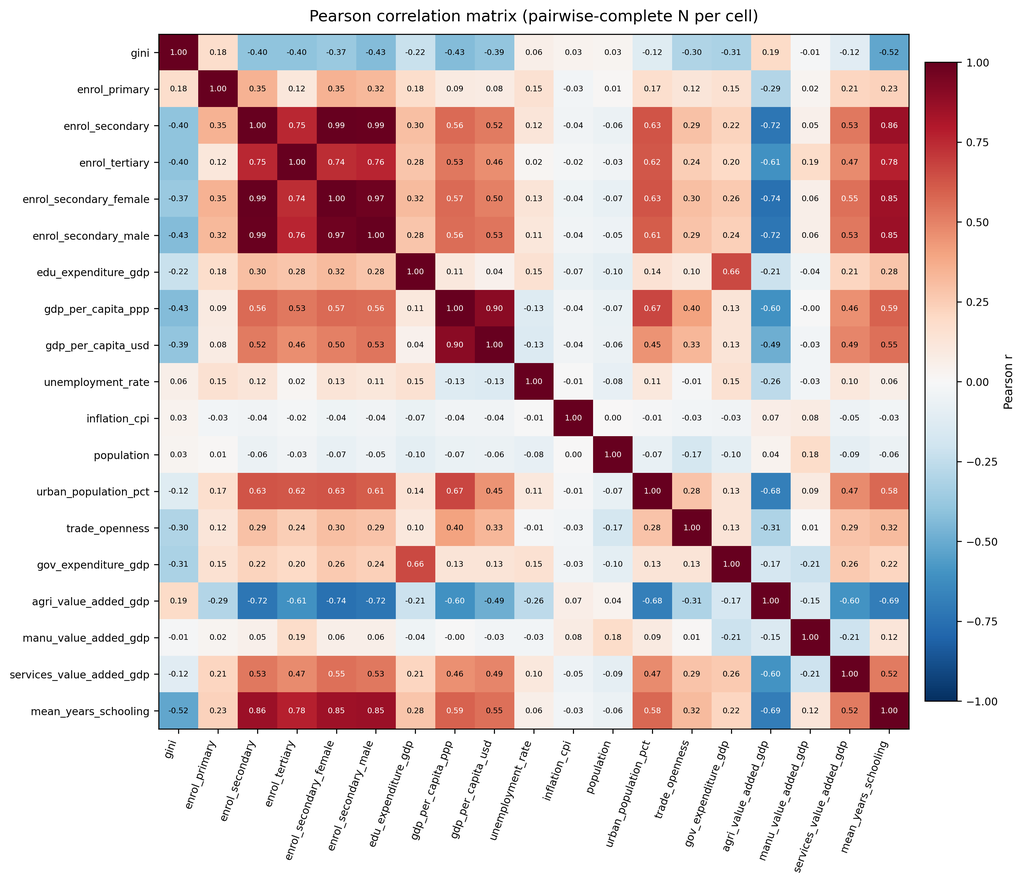

**VIF table (sorted descending):**

|  | variable | vif | flag |
| --- | --- | --- | --- |
| 0 | enrol_secondary | 40,587.89 | concern |
| 1 | enrol_secondary_female | 10,906.35 | concern |
| 2 | enrol_secondary_male | 9,652.91 | concern |
| 3 | gdp_per_capita_ppp | 14.39 | concern |
| 4 | gdp_per_capita_usd | 10.52 | concern |
| 5 | agri_value_added_gdp | 5.44 | watch |
| 6 | mean_years_schooling | 4.84 | ok |
| 7 | enrol_tertiary | 3.80 | ok |
| 8 | urban_population_pct | 2.95 | ok |
| 9 | services_value_added_gdp | 2.91 | ok |
| 10 | edu_expenditure_gdp | 2.08 | ok |
| 11 | gov_expenditure_gdp | 1.92 | ok |
| 12 | trade_openness | 1.62 | ok |
| 13 | manu_value_added_gdp | 1.41 | ok |
| 14 | unemployment_rate | 1.30 | ok |
| 15 | enrol_primary | 1.15 | ok |
| 16 | population | 1.12 | ok |
| 17 | inflation_cpi | 1.12 | ok |

**Top 5 |Pearson r| with gini:**

|  | variable | pearson_r_with_gini |
| --- | --- | --- |
| 0 | mean_years_schooling | -0.519825 |
| 1 | gdp_per_capita_ppp | -0.434366 |
| 2 | enrol_secondary_male | -0.431822 |
| 3 | enrol_secondary | -0.403982 |
| 4 | enrol_tertiary | -0.400920 |

```python
display(Image(filename=str(FIG_DIR / "phase03_s04_correlation_matrix.png")))

vif_df = pd.read_csv(TBL_DIR / "phase03_s04_vif.csv")
display(Markdown("**VIF table (sorted descending):**"))
display(vif_df.style.format({"vif": "{:,.2f}"}))

# Strongest |Pearson r| with gini.
corr = pd.read_csv(TBL_DIR / "phase03_s04_correlation_matrix.csv", index_col=0)
gini_corrs = corr["gini"].drop("gini").abs().sort_values(ascending=False)
top5 = pd.DataFrame({
    "variable": gini_corrs.head(5).index,
    "pearson_r_with_gini": [corr.loc[v, "gini"] for v in gini_corrs.head(5).index],
})
display(Markdown("**Top 5 |Pearson r| with gini:**"))
display(top5)
```

**Observation.** The correlation heatmap shows three structurally tight blocks: the secondary-enrolment trio (`enrol_secondary`, `enrol_secondary_female`, `enrol_secondary_male` correlate at 0.97–0.99 with each other), the GDP duo (`gdp_per_capita_ppp` and `gdp_per_capita_usd` at r = 0.90), and `agri_value_added_gdp` correlates strongly negatively with most "development" indicators (−0.72, −0.69, −0.68 with the secondary-enrolment trio, mean years of schooling, and urban population share respectively). The top-5 |Pearson r| with gini are `mean_years_schooling` (−0.52), `gdp_per_capita_ppp` (−0.43), `enrol_secondary_male` (−0.43), `enrol_secondary` (−0.40), and `enrol_tertiary` (−0.40) — all negative, all education or development indicators, all comparable in magnitude.

The VIF table makes the structural issue concrete. The secondary-enrolment trio carries VIFs in the 9,000–40,000 range — three orders of magnitude above the conventional concern threshold. The two GDP variables sit at 14.4 and 10.5. Below those, the highest VIF is `agri_value_added_gdp` at 5.4 (watch). Crucially, **the sector-share trio itself (`agri/manu/services_value_added_gdp`) does not all sit at the concern level** — `manu` is at 1.4 and `services` at 2.9.

**Explanation.** The four-digit VIFs on the secondary-enrolment trio reflect an arithmetic identity: the female and male series are nested inside the aggregate (`enrol_secondary` ≈ a population-weighted average of the gender-split series). This is not a statistical accident, it is a definition. The GDP duo is a measurement choice: PPP and USD are two representations of the same underlying quantity. The sector-share trio *sounds* like it should be near-singular because the three shares sum to near 100%, but in practice the WB sector classification leaves room for "net taxes on products" and other residuals, and the three series carry enough cross-country and within-country independent variation to avoid extreme collinearity. The pre-Phase-03 expectation that sector shares would dominate the multicollinearity diagnostics turns out to be overstated.

**Implication.** Phase 05's baseline specification will use exactly one of the secondary-enrolment trio (`enrol_secondary` is the natural choice; the gender-split variables will appear only in heterogeneity specifications). Exactly one of the GDP duo will be used (`ppp` is preferred per Scope §6.3 for cross-country comparability; `usd` is available as a robustness check). The sector shares are usable as three regressors in the baseline — a finding that allows a cleaner specification than initially expected.

## 6. Time-series by region and by income group

Cross-country mean lines with IQR bands show how `gini`, `mean_years_schooling`, and `enrol_secondary` evolve from 1990 to 2023, grouped first by World Bank region and then by income group. Strata with fewer than five countries are drawn as individual country lines (notably North America at n = 3, and a small "Not classified" income stratum at n = 2). The N_observed range printed in each subplot title indicates the year-by-year coverage of the variable within the figure.

By region

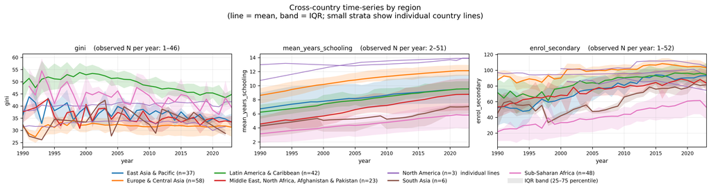

By income group

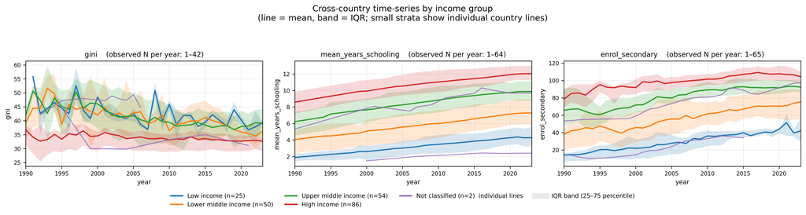

```python
display(Markdown("### By region"))
display(Image(filename=str(FIG_DIR / "phase03_s05_timeseries_by_region.png")))

display(Markdown("### By income group"))
display(Image(filename=str(FIG_DIR / "phase03_s05_timeseries_by_income.png")))
```

**Observation (income group).** Plotted by income group rather than geography, the Gini panel reveals a structurally different pattern. High income countries sit at the *bottom* of the distribution (~30, with a narrow IQR), upper-middle income at the top (~40, falling toward 35), and low income in between with substantial year-on-year noise. The mean years of schooling panel shows a clean stepped gradient (high ≫ upper middle ≫ lower middle ≫ low) with the gradient roughly preserved over time. The `enrol_secondary` panel shows a clear convergence: low-income countries have moved from ~15 toward ~45 secondary gross enrolment, narrowing the gap with high-income countries.

**Explanation.** The region-vs-income contrast is the most analytically important pattern in the time-series data. Geography sorts countries by the *direction* of inequality (Latin America high, Europe low) but the income-group cut suggests Gini follows a *non-monotonic* relationship with development — high-inequality countries are concentrated at the upper-middle income level rather than at the bottom. This is consistent with a Kuznets-type inverted-U, in which inequality rises during the transition from agrarian to industrial economies and falls again as service-sector economies mature. The convergence in secondary enrolment reflects the global push for universal secondary education following the Millennium Development Goals (1990–2015) and Sustainable Development Goals (2015 onward).

**Implication.** The region and income views answer different questions and motivate different downstream uses. Phase 04's clustering should not treat region as the primary structural axis — the Kuznets-type pattern in the income view suggests development-level features (`mys`, `gdp_per_capita_ppp`, sector shares) will carry the cluster-defining signal more cleanly than geographic dummies. Phase 05's heterogeneity specifications should consider income-group interactions because the Gini–education relationship plausibly has different slopes across the inverted-U. Phase 07's policy framing should be income-group rather than region first, and should be careful about the implicit "low-income = high-Gini" claim that the Kuznets pattern contradicts.

A footnote on the time-series construction. `enrol_secondary` is sparse before 2000 (Phase 02 missingness report: 4 countries with full 1990–2023 secondary enrolment coverage). The IQR bands shown for that variable in the early 1990s reflect a small and shifting set of countries and should be read with that in mind. `unemployment_rate` is not plotted here, but for any time-series including it the line should start at 1991 because the ILO modeled-series start year is 1991, not 1990.

## 7. Geographic visualisation

The choropleth maps below render `gini` and `mean_years_schooling` as country-level fills using ISO-3 country codes. For each variable the left panel shows the most recent year with broad coverage (Gini: 2021 with N = 81 country observations; mean years of schooling: 2022 with N = 193), and the right panel shows the panel-period mean across all years where the country has at least one observation. Maps are rendered with plotly and saved as standalone HTML files; the embedded interactive versions below are visible when this notebook is opened in a Jupyter runtime, and the linked HTML files can be opened directly in any browser.

```python
gini_html = FIG_DIR / "phase03_s06_choropleth_gini.html"
mys_html = FIG_DIR / "phase03_s06_choropleth_mys.html"

# IFrame src is interpreted relative to the notebook's own location, so
# from notebooks/03_eda.ipynb we need ../outputs/figures/<file>.html with
# forward slashes (HTML attribute convention) regardless of host OS.
GINI_IFRAME_SRC = "../outputs/figures/phase03_s06_choropleth_gini.html"
MYS_IFRAME_SRC = "../outputs/figures/phase03_s06_choropleth_mys.html"

display(Markdown(
    f"### Gini\n\n"
    f"Interactive map: [`phase03_s06_choropleth_gini.html`]({gini_html.relative_to(PROJECT_ROOT).as_posix()})"
))
try:
    display(IFrame(src=GINI_IFRAME_SRC, width="100%", height=480))
except Exception as exc:
    print(f"(IFrame embed not available in this rendering context: {exc}. "
          f"Open the HTML file directly via the link above.)")

display(Markdown(
    f"### Mean years of schooling\n\n"
    f"Interactive map: [`phase03_s06_choropleth_mys.html`]({mys_html.relative_to(PROJECT_ROOT).as_posix()})"
))
try:
    display(IFrame(src=MYS_IFRAME_SRC, width="100%", height=480))
except Exception as exc:
    print(f"(IFrame embed not available in this rendering context: {exc}. "
          f"Open the HTML file directly via the link above.)")
```

Gini

Interactive map: `phase03_s06_choropleth_gini.html`

[interactive chart not shown]

Mean years of schooling

Interactive map: `phase03_s06_choropleth_mys.html`

[interactive chart not shown]

**Observation.** The Gini map shows the highest Gini values concentrated in southern Africa and across much of Latin America; Europe and the post-Soviet states form a low-Gini band; Sub-Saharan Africa carries substantial within-region heterogeneity, partly because Gini coverage is genuinely sparse for several countries in the region. Mean years of schooling correlates visibly with high-income geography: North America, Europe, the Antipodes, and parts of East Asia in the highest band; South Asia and most of Sub-Saharan Africa in the lowest band; Latin America in the middle band.

**Explanation.** The visual division between the latest-year and panel- mean Gini maps is informative: countries that disappear in the latest-year map (visible in the panel mean but blank in 2021) are countries with no Gini observation in or near 2021 — predominantly low- and lower-middle income economies for which household-survey-based Gini calculations are infrequent or unavailable. This is the same MNAR pattern quantified in Phase 02 (Gini missingness report, 30% country-year density, only 3 countries with 34-year coverage), now visible geographically.

**Implication.** Geography, like income group, is a useful *display* axis but is not the cleanest *modelling* axis: the regional mean masks substantial within-region heterogeneity, and the geographic gaps in the Gini map are exactly where a fixed-effects panel specification will lose its identifying variation. Phase 04 clustering will work with the panel- mean values rather than a single year, which the right-panel maps visualise. Phase 07's policy framing should foreground rather than gloss over the spatial structure of missingness — the absent countries are not randomly absent.

## 8. Phase 03 findings — synthesis

Bringing the five diagnostic axes together, nine concrete findings carry forward into Phases 04, 05, and 07. They are listed in approximate order of analytical weight rather than by section.

1. **Mean years of schooling is the dominant single predictor.** OLS R² = 0.27 against Gini, slope ≈ −1.5 Gini points per additional year of schooling, top of the |Pearson r| ranking at −0.52. This is the anchor variable for any Phase 05 baseline specification.
2. **The secondary-enrolment trio is arithmetically nested.** VIFs in the 9,000–40,000 range force a choice: Phase 05 uses one of the three in the baseline (most likely `enrol_secondary`) and reserves the gender split for heterogeneity-only specifications.
3. **`enrol_primary` is non-monotonic with Gini.** The bivariate slope is essentially zero (R² = 0.03) with the wrong sign in linear form because high-Gini Latin American countries cluster at universal primary enrolment alongside low-Gini high-income countries. A linear primary- enrolment term will mislead.
4. **`edu_expenditure_gdp` is a null bivariate result.** R² = 0.05, negative LOWESS-vs-linear gap. Public spending share does not predict Gini directly — a finding that is itself a Phase 07 narrative point.
5. **Sector shares are not as collinear as expected.** Only `agri_value_added_gdp` enters the watch tier (VIF ≈ 5). All three sector shares are usable in a single specification, contrary to the *a priori* concern about sum-to-100 structural collinearity.
6. **`inflation_cpi` has an extreme right tail (skewness 52).** Treatment in Phase 05 will require log transformation, winsorisation, or a robust regression diagnostic.
7. **The income-group view of Gini is consistent with Kuznets.** Upper- middle income countries are most unequal; high-income least; low- income in between. This contradicts the casual "low-income = high- inequality" framing.
8. **Secondary enrolment shows clear convergence; mean years of schooling does not.** Phase 04 clustering should expect *level* differences in `mys` to persist as a cluster-defining feature, while *trajectory* in `enrol_secondary` should look more uniform.
9. **Two countries are "Not classified" in the WB income taxonomy.** A small structural finding inherited into Phase 02 only at this stage. It does not affect the baseline analysis but should be flagged in any income-stratified table.

## 9. Limitations

Three known constraints inherited from earlier phases shape the interpretation of every figure above, and three new caveats surface in Phase 03 itself.

**Inherited.** First, Gini is the binding sample constraint at 30% country-year completeness; only 3 of 217 countries have full 1990–2023 coverage (Phase 02). Phase 05's listwise samples will be roughly an order of magnitude smaller than the 7,378-row panel. Second, Gini missingness is plausibly MNAR — concentrated in lower-income countries — so any conclusion drawn from a Gini-conditioned sample inherits a selection bias that no listwise procedure can correct. Third, cross-country Gini values are measured heterogeneously (consumption- vs income-based; pre- vs post-tax) and these differences will be partly absorbed by the fixed-effects specification in Phase 05 but cannot be eliminated.

**Surfaced in Phase 03.** Fourth, `enrol_primary` is structurally bounded above by the 100% gross-enrolment ceiling and below by the developing- world floor, producing a non-linear relationship that any single-term linear specification will mis-fit. Fifth, the country sample for the sub-2000 enrolment series is small and shifting; figures that span 1990– 2023 should be interpreted as a description of the available data, not of the world. Sixth, the LOWESS-vs-linear comparison reported here uses LOWESS R² as a non-linearity hint, not as a model-selection criterion; the apparent "non-linearity" of `enrol_primary` could be an artefact of the ceiling and the regional mixing rather than a true non-linear causal form.

## 10. Handoff to Phase 04

Phase 04's country clustering inherits from Phase 03 a clear short list of cluster-defining features: `mean_years_schooling`, `gdp_per_capita_ppp` (in log form), `enrol_secondary`, and the three sector-share variables. The income-group view's Kuznets-type pattern motivates clustering on *development-level* features rather than on regional dummies. Cluster profiles should report mean Gini per cluster as a descriptive — not explanatory — statistic.

Phase 05's econometric modelling inherits a clear specification template:

- baseline: `gini ~ mean_years_schooling + enrol_secondary + log(gdp_ppp) + log(population) + urban_population_pct`
- with sector shares: add `agri/manu/services_value_added_gdp`
- heterogeneity: replace `enrol_secondary` with `enrol_secondary_female` and `enrol_secondary_male`
- robustness: substitute `gdp_per_capita_usd` for `gdp_per_capita_ppp`, apply a winsorised or log-transformed `inflation_cpi`

Phase 07's synthesis inherits three named threats to identification that are now grounded in concrete numbers: MNAR Gini missingness (30% country-year completeness, geographic concentration), Gini measurement heterogeneity, and the input-vs-attainment distinction (`edu_expenditure_gdp` null result alongside the strong `mean_years_schooling` signal).

*Notebook generated and executed by `scripts/phase03_s07_build_notebook.py`. Source data: `data/processed/panel.csv`. Figures and tables under `outputs/figures/` and `outputs/tables/` are produced by step scripts `phase03_s02` through `phase03_s06`. Reproduction instructions:* *`README.md` § Installation and Usage.*